# Lab 03 - Parametric and Nonparametric Univariate Tests

```r
p.value <- numeric(B)
#pb=progress_bar$new(total=B)
#pb$tick(0)
set.seed(seed)
for(j in 1:B)
{
  campione = rt(2*n, 1)
  x.1 = campione[1:n]
  x.2 = campione[-(1:n)]
  #x.1 <- rt(n,1)
  #x.2 <- rt(n,1)

  p.value[j] <- t.test(x.1,y=x.2)$p.value
  #pb$tick()
}
```

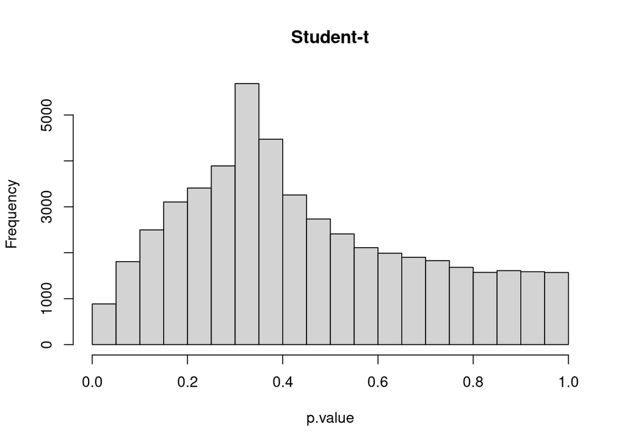

```r
hist(p.value, main = 'Student-t')
```

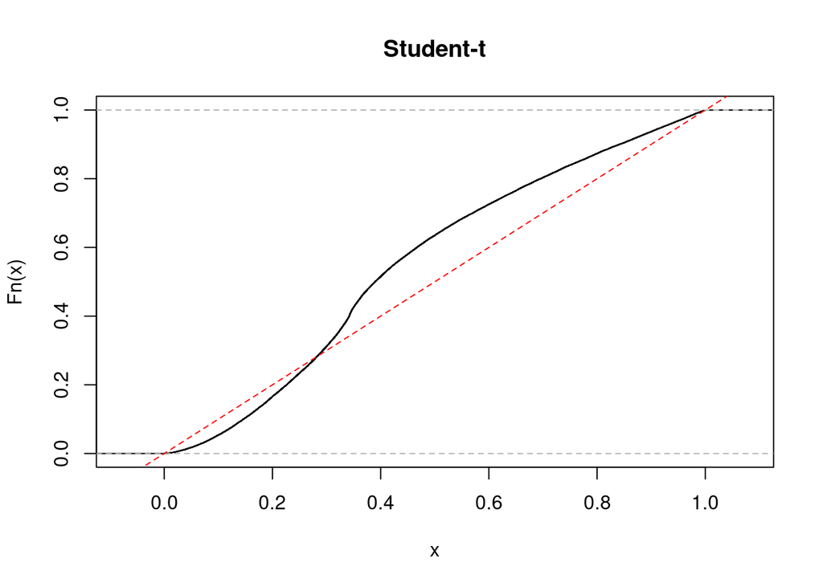

```r
plot(ecdf(p.value), main = 'Student-t')
abline(0,1, lty=2, col='red')
```

In this case I am starting to see a departure from uniformness… that reflects on the empirical type-I error!

```r
estimated.alpha <- sum(p.value < alpha)/B
c(estimated.alpha - sqrt(estimated.alpha*(1-estimated.alpha)/B)*qnorm(0.975), estimated.alpha, estimated.alpha + sqrt(estimated.alpha*(1-estimated.alpha)/B)*qnorm(0.975))
```

```
## [1] 0.01654423 0.01770000 0.01885577
```

So my test is not exact anymore! I can actually replicate this with several other possible cases…

```r
library(stabledist)
```

`stabledist` is a quite useful package used to simulate from “stable” distributions, where a stable distribution intended is in the Levy sense: i.e. if a linear combination of two variables generated from a stable distribution P is still distributed as P. Parametrisation is done with

- $\alpha$ = stability, from 0 to 2
- $\beta$ = skewness parameter
- $\mu$ = location

In stable distributions, the mean is actually defined only for $\alpha>1$, while variance is defined only for $\alpha=2$ Stable distributions are very useful to simulate heavy-tailed data…

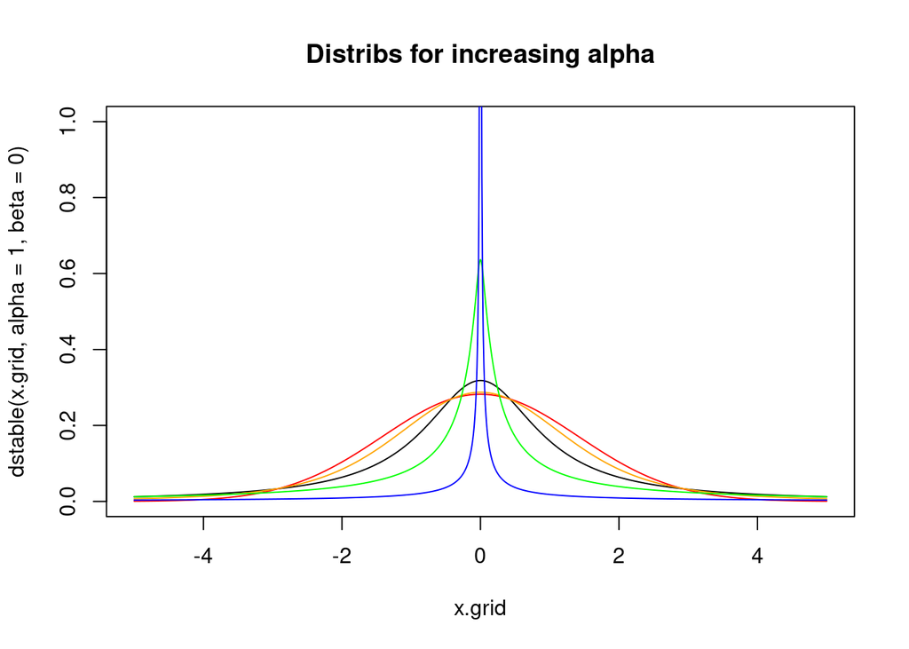

```r
x.grid <- seq(-5, 5, by=0.01)
plot(x.grid, dstable(x.grid,
                     alpha=1,
                     beta=0), ylim=c(0,1), type='l', main="Distribs for increasing alpha") #cauchy
lines(x.grid, dstable(x.grid,2,0), type='l',col="red") #normal
lines(x.grid, dstable(x.grid,1.5,0), type='l',col="orange")
lines(x.grid, dstable(x.grid,0.5,0), type='l',col="green")
lines(x.grid, dstable(x.grid,0.1,0), type='l',col="blue")
```

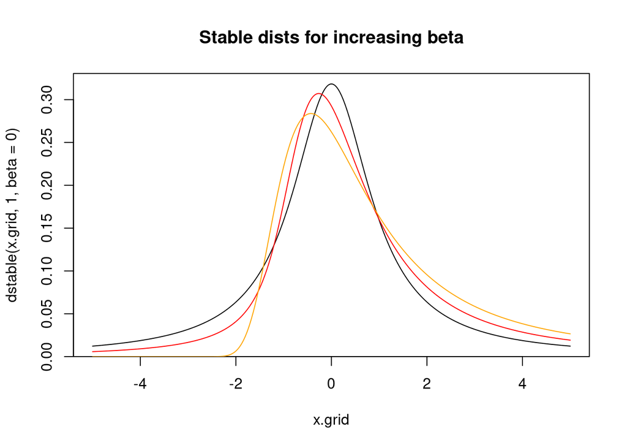

```r
plot(x.grid, dstable(x.grid,1,beta=0), type='l', main="Stable dists for increasing beta") #cauchy
lines(x.grid, dstable(x.grid,1,beta=0.5), type='l',col="red")
lines(x.grid, dstable(x.grid,1,beta=1), type='l',col="orange")
```

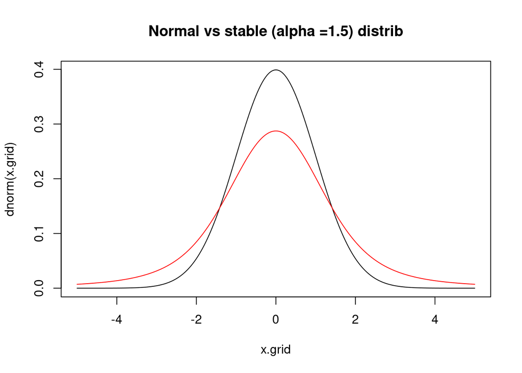

```r
x.grid <- seq(-5, 5, by=0.01)
plot(x.grid, dnorm(x.grid), type='l', main="Normal vs stable (alpha =1.5) distrib")
lines(x.grid, dstable(x.grid,1.5,0), type='l',col='red')
```

```r
p.value <- numeric(B)
#pb=progress_bar$new(total=B)
#pb$tick(0)
set.seed(seed)
for(j in 1:B)
{
  x.1 <- rstable(n,1.5,0)
  x.2 = rstable(n,1.5,0)
  p.value[j] <- t.test(x.1,y=x.2)$p.value
  #pb$tick()
}
```

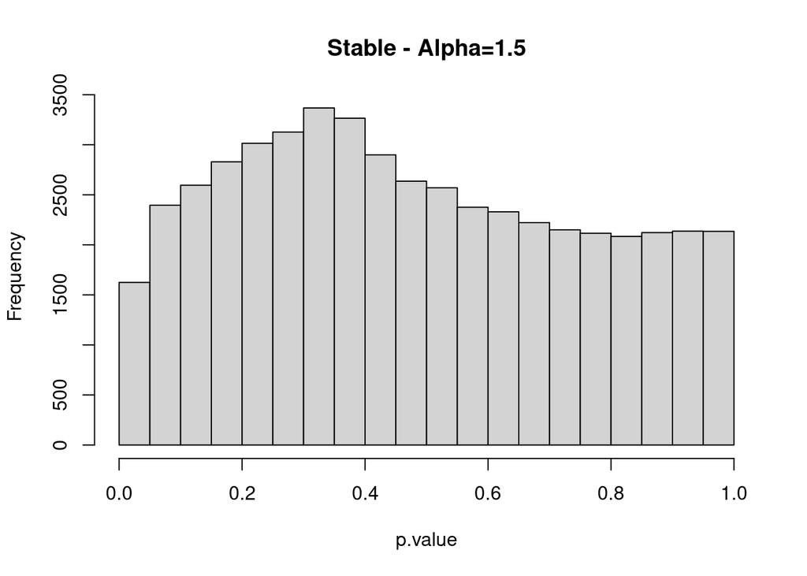

```r
hist(p.value, main = 'Stable - Alpha=1.5')
```

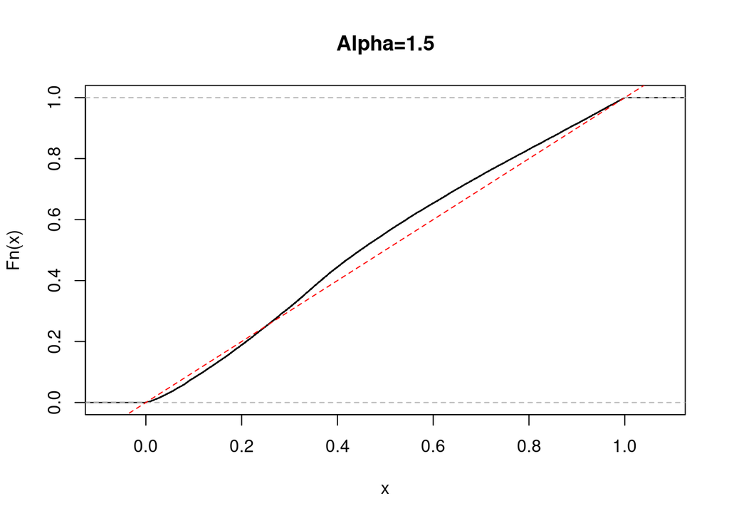

```r
plot(ecdf(p.value), main = 'Alpha=1.5')
abline(0,1, lty=2, col='red')
```

```r
estimated.alpha <- sum(p.value < alpha)/B
c(estimated.alpha - sqrt(estimated.alpha*(1-estimated.alpha)/B)*qnorm(0.975), estimated.alpha, estimated.alpha + sqrt(estimated.alpha*(1-estimated.alpha)/B)*qnorm(0.975))
```

```
## [1] 0.03094572 0.03250000 0.03405428
```

Same conclusions as before, the p-value is not distributed as a uniform, and my test is not exact anymore![^4]

What happens instead with something with $\alpha=0.5$?

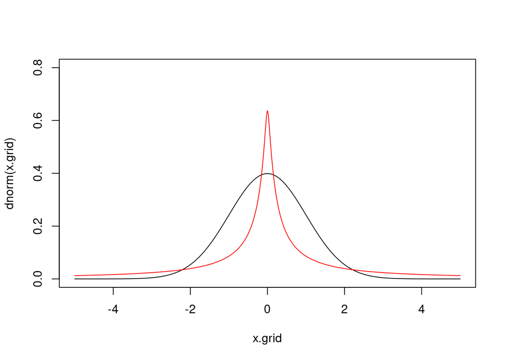

```r
plot(x.grid, dnorm(x.grid), type='l', ylim=c(0,.8))
lines(x.grid, dstable(x.grid,.5,0), type='l',col='red')
```

```r
p.value <- numeric(B)
#pb=progress_bar$new(total=B)
#pb$tick(0)
set.seed(seed)
for(j in 1:B)
{
  x.1 <- rstable(n,.5,0)
  x.2 = rstable(n,.5,0)
  p.value[j] <- t.test(x.1,y=x.2)$p.value
  #pb$tick()
  }
```

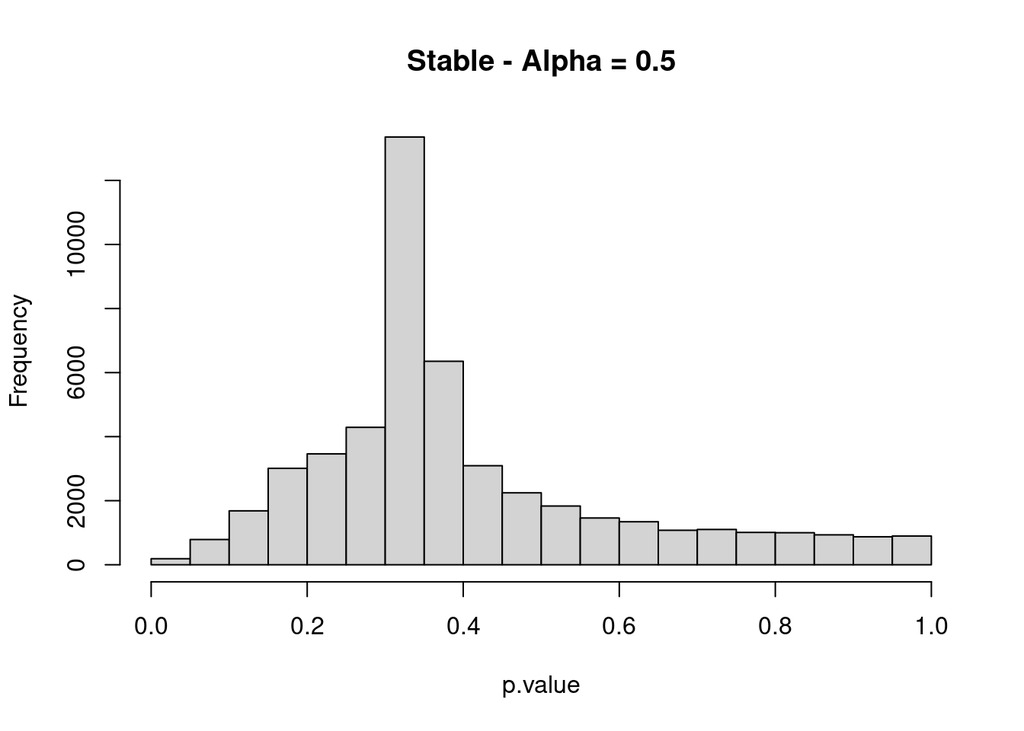

```r
hist(p.value, main = 'Stable - Alpha = 0.5')
```

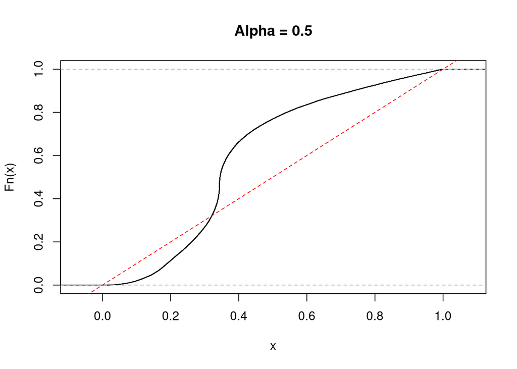

```r
plot(ecdf(p.value), main = 'Alpha = 0.5')
abline(0,1, lty=2, col='red')
```

```r
estimated.alpha <- sum(p.value < alpha)/B
c(estimated.alpha - sqrt(estimated.alpha*(1-estimated.alpha)/B)*qnorm(0.975), estimated.alpha, estimated.alpha + sqrt(estimated.alpha*(1-estimated.alpha)/B)*qnorm(0.975))
```

```
## [1] 0.003242118 0.003780000 0.004317882
```

Again, the empirical p-value of the test is lower than the nominal one.

###### Exercise

Explore the empirical type I error of the t-test when the distibution is highly skewed. What do you observe?

Let’s use the $\alpha=1.5$ example as a testbed: we have seen that the t-test to check equality in distribution in this case is a TERRIBLE idea, let’s see though how nonparametric tests behave.

### Exploiting Nonparametric tests

Let’s see what’s going on with Mann-Whitney U test. Recall that we have, for two independent random samples

$$H_0: X \stackrel{d}{=}Y \;\; versus \;\; H_1: \mathbb{P}[X>Y] \neq
0.5$$
Counterintutively, we perform such test with the use of the `wilcox.test` function, setting the `paired` argument as `FALSE`, and filling arguments `x` and `y` with the respective samples

For the one sample signed-rank test, we run `wilcox.test` giving a value only `x` and setting `y=NULL`. For the two-sample paired Wilcoxon test, `wilcox.test` is used with values for `x`, `y` and `paired=T`.

```r
p.value <- numeric(B)
#pb=progress_bar$new(total=B)
#pb$tick(0)
set.seed(seed)
for(j in 1:B)
{
  x.1 <- rstable(n,1.5,0)
  x.2 = rstable(n,1.5,0)
  p.value[j] <- wilcox.test(x.1,y=x.2, paired=F, conf.level = 1-alpha)$p.value
  #pb$tick()
}
```

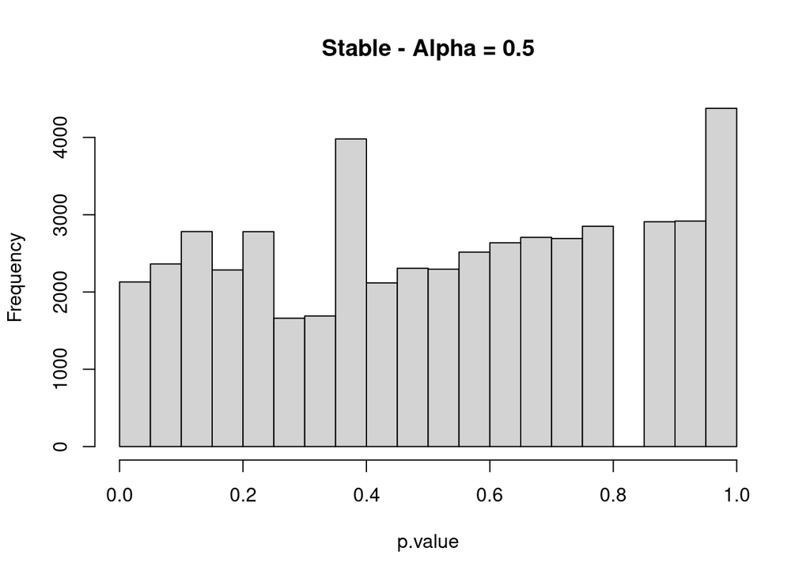

```r
hist(p.value, main = 'Stable - Alpha = 0.5')
```

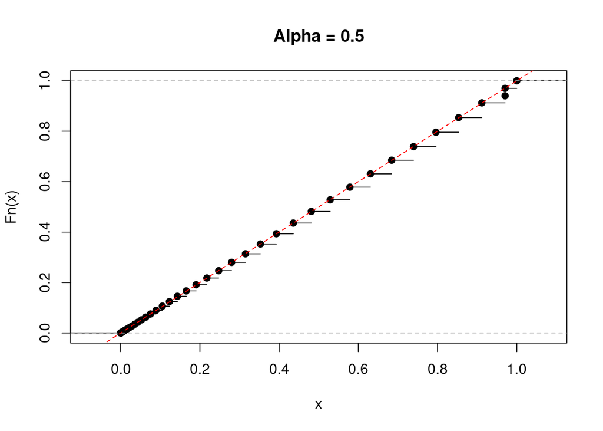

```r
plot(ecdf(p.value), main = 'Alpha = 0.5')
abline(0,1, lty=2, col='red')
```

```r
estimated.alpha <- sum(p.value < alpha)/B
c(lower=estimated.alpha - sqrt(estimated.alpha*(1-estimated.alpha)/B)*qnorm(0.975),
  point=estimated.alpha,
  upper=estimated.alpha + sqrt(estimated.alpha*(1-estimated.alpha)/B)*qnorm(0.975))
```

```
##      lower      point      upper
## 0.04082983 0.04260000 0.04437017
```

Quite unfortunately for you, to my (and prof. Vantini’s knowledge) there are no particularly good implementations in R for permutation tests… so we need to “weaponise” his code, putting it into a function that we can call when we need it.

Before looking at the code, let us recall the setting. We want to test is $H_0: Y_1\stackrel{d}{=}Y_2$ vs $H_1: Y_1 \stackrel{d}{\neq} Y_2$. For this, we have two sample:. Following Prof. Vantini’s notation: $\mathcal{X}_p$ is an observed pooled sample.

To test this, we use a statistic $T_0$ (in this case $|\bar{x}_1-\bar{x}_1|$) conditional on the fact the observed pooled sample is $X_p$. Id est, we look at the distribution of
$$T_0 | X_p \in [ \mathcal{X}_p ]$$
Remark: even though we are doing inference with, the permutation test is **unconditionally valid** (check class notes for proof)

```r
perm_t_test=function(x,y,iter=1e3){

  T0=abs(mean(x)-mean(y))  # define the test statistic
  T_stat=numeric(iter) # a vector to store the values of each iteration
  x_pooled=c(x,y) # pooled sample
  n=length(x_pooled)
  n1=length(x)
  print(sprintf("Using %s iterations to estimate the permutational distribution. There are actually %s possible permutations", iter, factorial(n)))
  for(perm in 1:iter){ # loop for conditional MC
    # permutation:
    permutation <- sample(1:n)
    x_perm <- x_pooled[permutation]
    x1_perm <- x_perm[1:n1]
    x2_perm <- x_perm[(n1+1):n]
    # test statistic:
    T_stat[perm] <- abs(mean(x1_perm) - mean(x2_perm))

  }

  # p-value
  p_val <- sum(T_stat>=T0)/iter
  return(p_val)
}
```

```r
B2 = 1e4
p.value <- numeric(B2)

#pb=progress_bar$new(total=B)
#pb$tick(0)
set.seed(seed)
for(j in 1:B2)
{
  x.1 <- rstable(n,1.5,0)
  x.2 = rstable(n,1.5,0)
  p.value[j] <- perm_t_test(x.1,x.2,iter=1e3)
  #pb$tick()
}
```

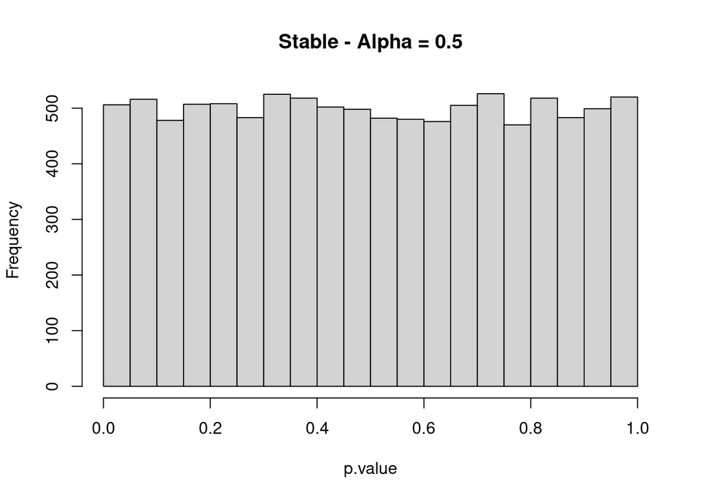

```r
hist(p.value, main = 'Stable - Alpha = 0.5')
```

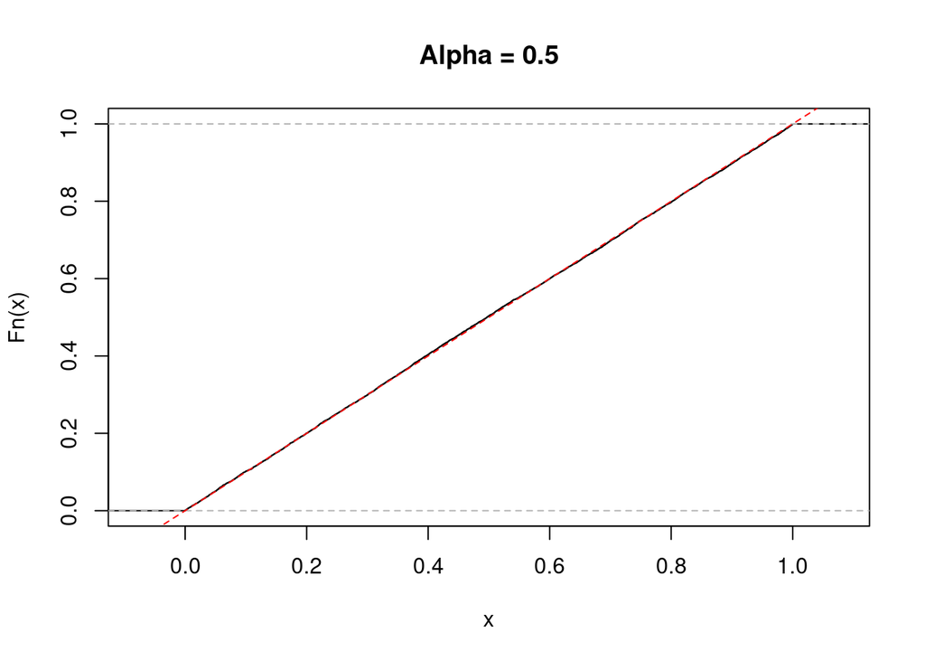

```r
plot(ecdf(p.value), main = 'Alpha = 0.5')
abline(0,1, lty=2, col='red')
```

```r
estimated.alpha <- sum(p.value < alpha)/B2
c(lower=estimated.alpha - sqrt(estimated.alpha*(1-estimated.alpha)/B)*qnorm(0.975), estimate=estimated.alpha,
  upper=estimated.alpha + sqrt(estimated.alpha*(1-estimated.alpha)/B)*qnorm(0.975))
```

```
##      lower   estimate      upper
## 0.04828605 0.05020000 0.05211395
```

The p-value is actually distributed as a uniform (discrete also in this case) and the empirical type-I error is fine.

## Assessment Empirical Level of Type-II error

Recall: type II error $\beta$ means not seeing something (deem $H_0$ true) that is actually there ($H_1$ is true). Its counterpart is the power of the test $1-\beta$, i.e. percentage of the times we $H_1$ when it is true.

How do I compare “valid” (i.e. tests where the theoretical type-I error is equal to the empirical one?) via the Type-II error, or the statistical power of the test (which is 1 minus type-II error)

In “easy” cases the power can be assessed analytically. For Wilcoxon and Permutation tests, we need simulation. Let us select the hardest case, so a stable with $\alpha=0.5$, and, fixed the data and the significance level, let’s cycle over a grid of effect sizes, and see what is the most powerful test in identifying things.

The algorithm is the following:

- A grid of delta of location shifts is defined
- For each value of delta, $B$ statistical tests are carried out.
- With the $B$ p-values, the percentage of runs in which $H_1$ was detected is computed

```r
delta_grid=seq(.5,2,by=.5) # very useful function ;)
set.seed(seed)
B <- 1e3
```

```r
# Empirical power of the Mann-Whitney test
power_wilcox=numeric(length(delta_grid))
for(ii in 1:length(delta_grid)){
      p.value <- numeric(B)
      #pb=progress_bar$new(total=B)
      #pb$tick(0)
      delta=delta_grid[ii]
      for(j in 1:B){

        x.1 <- rstable(n,0.5,0)
        x.2 = rstable(n,0.5,0,delta=delta)
        p.value[j] <- wilcox.test(x.1,y=x.2,correct = T)$p.value
        #pb$tick()
        }

      estimated.power <- sum(p.value < alpha)/B
      power_wilcox[ii]=estimated.power
}
```

```r
# Empirical power of the Permutation t-test
power_perm_1=numeric(length(delta_grid))
set.seed(seed)
for(ii in 1:length(delta_grid)){
  p.value <- numeric(B)
  pb=progress_bar$new(total=B)
  pb$tick(0)
  delta=delta_grid[ii]
  for(j in 1:B){

    x.1 <- rstable(n,0.5,0)
    x.2 = rstable(n,0.5,0,delta=delta)
    p.value[j] <- perm_t_test(x.1,x.2,iter=500)
    pb$tick()
    }

  estimated.power <- sum(p.value < alpha)/B
  power_perm_1[ii]=estimated.power
}
```

Let’s also add to our comparison a more exotic version of permutation test: instead of using the mean, let’s use the median…

```r
perm_median_test=function(x,y,iter=1e3){


  T0=abs(median(x)-median(y))  # test statistic: here we use the medians instead of the means
  T_stat=numeric(iter)
  x_pooled=c(x,y)
  n=length(x_pooled)
  n1=length(x)
  for(perm in 1:iter){
    # permutation:
    permutation <- sample(1:n)
    x_perm <- x_pooled[permutation]
    x1_perm <- x_perm[1:n1]
    x2_perm <- x_perm[(n1+1):n]
    # test statistic:
    T_stat[perm] <- abs(median(x1_perm) - median(x2_perm))
  }
  # p-value
  p_val <- sum(T_stat>=T0)/iter
  return(p_val)

}
```

```r
power_perm=numeric(length(delta_grid))
set.seed(seed)
for(ii in 1:length(delta_grid)){
  p.value <- numeric(B)
  #pb=progress_bar$new(total=B)
  #pb$tick(0)
  delta=delta_grid[ii]
  for(j in 1:B){

    x.1 <- rstable(n,0.5,0)
    x.2 = rstable(n,0.5,0,delta=delta)
    p.value[j] <- perm_median_test(x.1,x.2,iter=100)
    #pb$tick()
    }

  estimated.power <- sum(p.value < alpha)/B
  power_perm[ii]=estimated.power
}
```

And now, we visualise the typical “power-delta plot”.

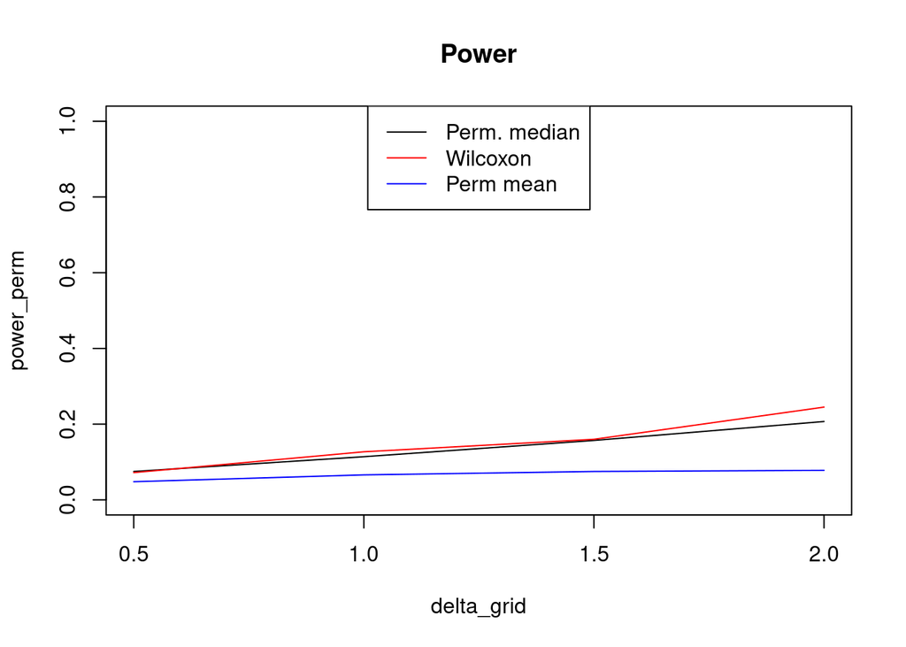

```r
plot(delta_grid,power_perm,type='l', main='Power',ylim=c(0,1))
lines(delta_grid,power_wilcox,col='red')
lines(delta_grid,power_perm_1,col='blue')
legend(x="top",legend=c("Perm. median", "Wilcoxon", "Perm mean"), col=c("black", "red", "blue"), lty=1, lwd=1)
```

What’s happening here? Why such a low power for the mean-based permutation test? Think about it…[^5]

And again, what happens, instead, when I use a nonparametric test while I could’ve used a parametric one?

```r
delta_grid=seq(.1,1,by=.2)

power_perm=numeric(length(delta_grid))
set.seed(seed)
for(ii in 1:length(delta_grid)){
  p.value <- numeric(B)
  #pb=progress_bar$new(total=B)
  #pb$tick(0)
  delta=delta_grid[ii]
  for(j in 1:B){

    x.1 <- rnorm(100)
    x.2 = rnorm(100,mean=delta)
    p.value[j] <- perm_t_test(x.1,x.2,iter=1000)
    #pb$tick()
    }

  estimated.power <- sum(p.value < alpha)/B
  power_perm[ii]=estimated.power
}
```

```r
set.seed(seed)
power_wilcox=numeric(length(delta_grid))
for(ii in 1:length(delta_grid)){
  p.value <- numeric(B)
  #pb=progress_bar$new(total=B)
  #pb$tick(0)
  delta=delta_grid[ii]
  for(j in 1:B){

    x.1 <- rnorm(100)
    x.2 = rnorm(100,mean=delta)
    p.value[j] <- wilcox.test(x.1,y=x.2,correct = T)$p.value
    #pb$tick()
    }

  estimated.power <- sum(p.value < alpha)/B
  power_wilcox[ii]=estimated.power
}
```

```r
set.seed(seed)
power_t=numeric(length(delta_grid)) #I can actually compute in an analytical fashion, but let's go with sim also here.
for(ii in 1:length(delta_grid)){
  p.value <- numeric(B)
  #pb=progress_bar$new(total=B)
  #pb$tick(0)
  delta=delta_grid[ii]
  for(j in 1:B){

    x.1 <- rnorm(100)
    x.2 = rnorm(100,mean=delta)
    p.value[j] <- t.test(x.1,y=x.2)$p.value
    #pb$tick()
    }

  estimated.power <- sum(p.value < alpha)/B
  power_t[ii]=estimated.power
}
```

Let’s add some “spice” to this last calculation…

```r
set.seed(seed)
power_median=numeric(length(delta_grid))
for(ii in 1:length(delta_grid)){
  p.value <- numeric(B)
  pb=progress_bar$new(total=B, format = "  computing [:bar] :percent eta: :eta")
  pb$tick(0)
  delta=delta_grid[ii]
  for(j in 1:B){

    x.1 <- rnorm(100)
    x.2 = rnorm(100,mean=delta)
    p.value[j] <- perm_median_test(x.1,x.2,iter=1000)
    pb$tick()
    }

  estimated.power <- sum(p.value < alpha)/B
  power_median[ii]=estimated.power
}
```

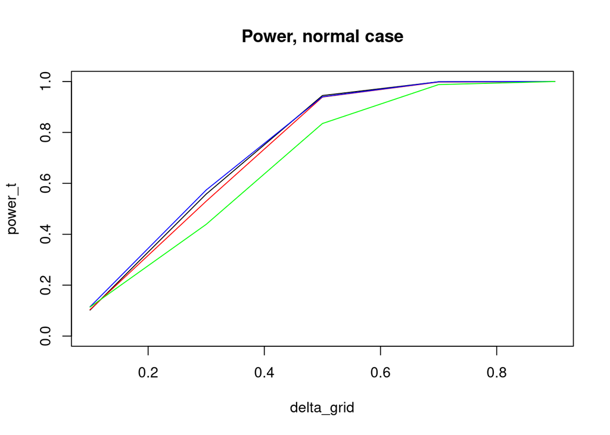

```r
plot(delta_grid,power_t,ylim=c(0,1), main='Power, normal case',type='l')
lines(delta_grid,power_wilcox,col='red')
lines(delta_grid,power_perm,col='blue')
lines(delta_grid,power_median,col='green')
```

So, apart from wasting some time with the computation, you’re not actually losing much… ;)

First, the power of the parametric test:

```r
set.seed(seed)
power_t=numeric(length(delta_grid)) #I can actually compute in an analytical fashion, but let's go with sim also here.
for(ii in 1:length(delta_grid)){
  p.value <- numeric(B)
  #pb=progress_bar$new(total=B)
  #pb$tick(0)
  delta=delta_grid[ii]
  for(j in 1:B){

    x.1 <- runif(100,0,6)
    x.2 = runif(100,0+delta,6+delta)
    p.value[j] <- t.test(x.1,y=x.2)$p.value
    #pb$tick()
    }

  estimated.power <- sum(p.value < alpha)/B
  power_t[ii]=estimated.power
}
```

And its permutational counterpart:

```r
power_perm_1=numeric(length(delta_grid))
set.seed(seed)
for(ii in 1:length(delta_grid)){
  p.value <- numeric(B)
  pb=progress_bar$new(total=B)
  pb$tick(0)
  delta=delta_grid[ii]
  for(j in 1:B){

    x.1 <- runif(100,0,6)
    x.2 = runif(100,0+delta,6+delta)
    p.value[j] <- perm_t_test(x.1,x.2,iter=1e3)
    pb$tick()
    }

  estimated.power <- sum(p.value < alpha)/B
  power_perm_1[ii]=estimated.power
}
```

We finally plot:

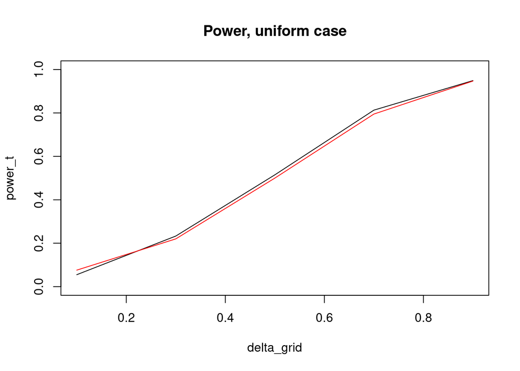

```r
plot(delta_grid,power_t,ylim=c(0,1), main='Power, uniform case',type='l')
lines(delta_grid,power_perm_1,col='red')
```

## Two-sample paired / one sample nonparametric test

Let us change the setting. We have made the empirical assessments of coverage (type-I error $\alpha$) and power ($1-$ type II error $\beta$) for tests for two independent samples. What about the other cases? We may have a sample of a univariate distribution, or paired observations. To elaborate on this, we load the dataset of last year’s February exam:

```r
data <- readRDS(file="./data/feb2024.rds")
df1 <- data$df1
df.tte <- data$df.tte
SEED <- 2024
B <- 1e3
ALPHA <- 0.01

months <- names(df1)[3:14]
print(months)
```

```
##  [1] "Brumaire"     "Frimaire"     "Nivôse"       "Pluviôse"     "Ventôse"
##  [6] "Germinal"     "Floréal"      "Prairial"     "Messidor"     "Thermidor"
## [11] "Fructidor"    "Vendémmiaire"
```

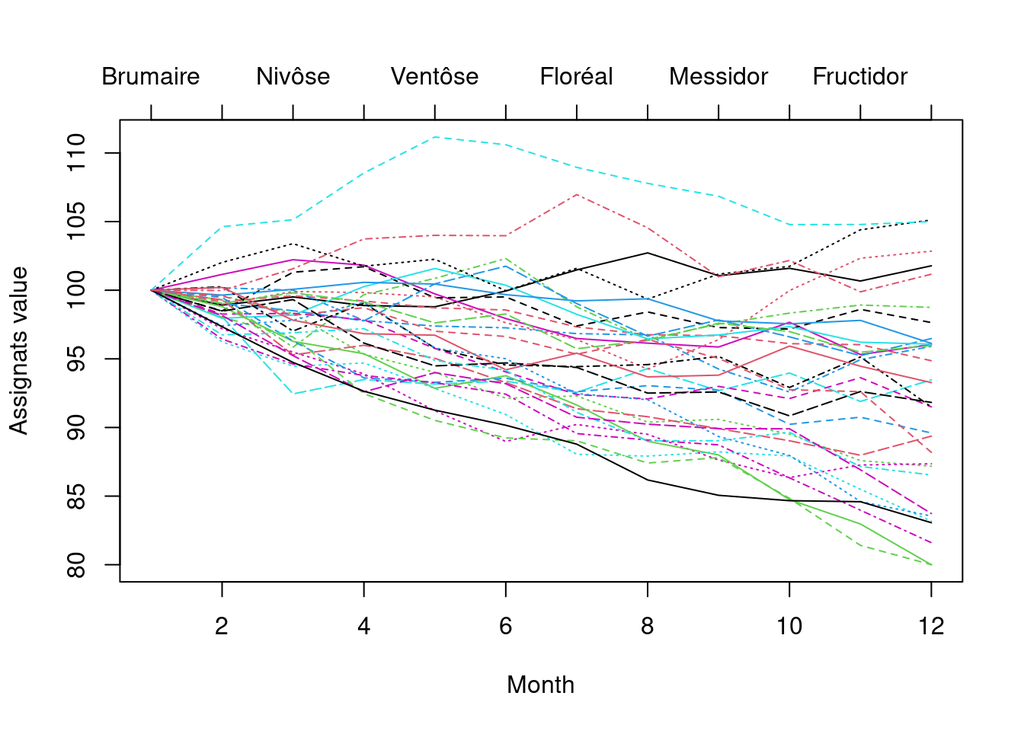

```r
matplot(t(df1[, 3:14]), type="l", xlab="Month", ylab="Assignats value")
axis(side=3,at=1:12,labels=months)
```

We assume the functions to be i.i.d statistical units. If you are doing the $5$-CFU version of the course, do not worry. This only means that data joined by the lines are paired.

Let $X_{floréal}$ be the R.V. that denotes the price of $assignats$ and $\mathcal{X}_{floréal}$ the collected samples of that variable.

### Sign test for the median of univariate data

We are interested in its median. Is it $100$? Id est, we perform the following test:
$$H_0 = \{ \mathbb{P}[X_{floréal} > 100] = 0.5 \}$$
*versus*
$$H_1 = \{ \mathbb{P} [X_{floréal} > 100] \neq 0.5 \}$$
since data are univariate and i.i.d, we can apply a sign test. The test statistic is going to be:
$$w^* :=
max(w, N-w)$$
where
$$w := \sum_{i=1}^{N} \mathbb{I}_{\{x_i > 100 \}}$$
That is, the count of data points that are higher than the hypothesised median (naturally $x_i$ denotes the $i$th statistical unit present in the sample $\mathcal{X}_{floréal}$ and $N$ is the sample size).

Assumptions:

- Observations are i.i.d.
- Under H0, the test statistic has the following property:

$$w^* \stackrel{H_0}{\sim} Binomial(N, 0.5)$$

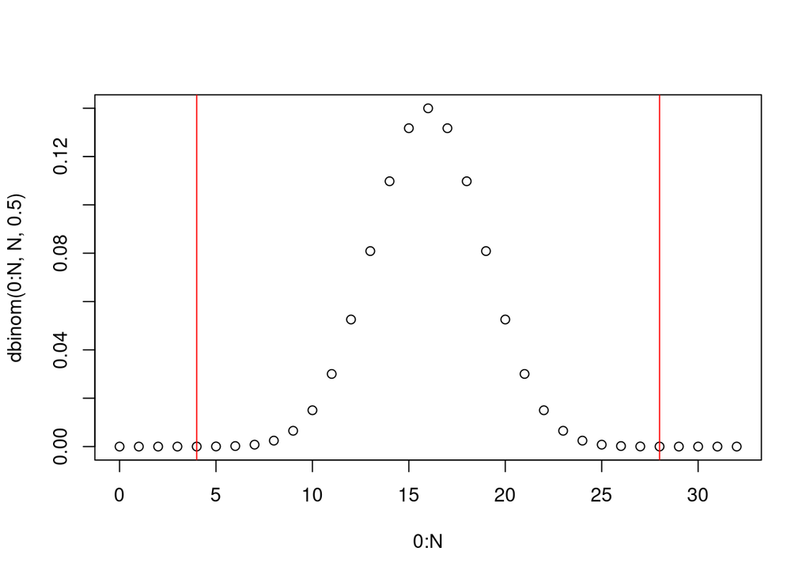

```r
median.h0 <- 100
N <- length(df1$Floréal)
w <- sum(df1$Floréal > median.h0)
w.star <- max(c(w, N - w))

# plot distribution under H_0
plot(0:N, dbinom(0:N, N, 0.5))
# add value of test statistic obtained with the sample
abline(v = c(w, N-w), col='red')
```

We calculate the p-value $p$ in the following way:
$$p = \mathbb{P}_{H_0}[W^* \geq w^* ] = 2 \sum_{n=w*}^N
\binom{N}{n}0.5^n(1-0.5)^{N-n}$$
(we calculate the mass of the right tail of the binomial distribution using the value of the statistic obtained with the sample and multiply it by two since it is symmetric about $0.5n$)

```r
p.value <- 2*(1 - pbinom(w.star-1, N, 0.5, lower.tail = T) )
p.value
```

```
## [1] 1.930119e-05
```

Which can be computed manually:

```r
bin.pmf <- function(x) (choose(N, x) * 0.5^x *(1-0.5)**(N-x))

p.value <- 2 * (1 - sum(sapply(1:(w.star-1),  FUN=bin.pmf ))
                )
p.value
```

```
## [1] 1.930166e-05
```

Moreover, is tantamount to [^6]:

```r
p.value <- 2*( pbinom(w.star-1, N, 0.5, lower.tail = F) )
p.value
```

```
## [1] 1.930119e-05
```

Or **much more simply**:

```r
binom.test(sum(w), N, p=0.5, alternative="two.sided",
           conf.level = 1-ALPHA)
```

```
##
##  Exact binomial test
##
## data:  sum(w) and N
## number of successes = 4, number of trials = 32, p-value = 1.93e-05
## alternative hypothesis: true probability of success is not equal to 0.5
## 99 percent confidence interval:
##  0.02181492 0.34377751
## sample estimates:
## probability of success
##                  0.125
```

The p-value is practically zero (which is coherent with the fact the value we obtained of the statistic is positioned at the tails of the distribution), meaning we reject $H_0$ in favour of $H_1$: we have statistical evidence to assert that the median price of assignats is different from $100$. (Alternatively, we could state that the confidence interval obtained from the Binomial distribution does not contain the value under $H_0$ so we reject $H_0$).

**Reminder**. Since we are using a discrete distribution for testing, there will be a finite quantity of achievable p-values, in this case dependent on the binomial distribution.

### Sign test for the quantile of univariate data

What if we were interested in the $90$th quantile ($q_{90}$) of $X_{floréal}$? As mentioned in class, we can still use the sign test. We try with $q_{90}=105$:
$$H_0 = \{ \mathbb{P}[X_{floréal} \leq 105] = 0.9 \}$$
*versus*
$$H_1 = \{ \mathbb{P} [X_{floréal} \leq 105] \neq 0.9 \}$$
since data are univariate and i.i.d, we can apply a sign test.

Having that:

$$(N-w) \stackrel{H_0}{\sim} Binomial(N, .90)$$

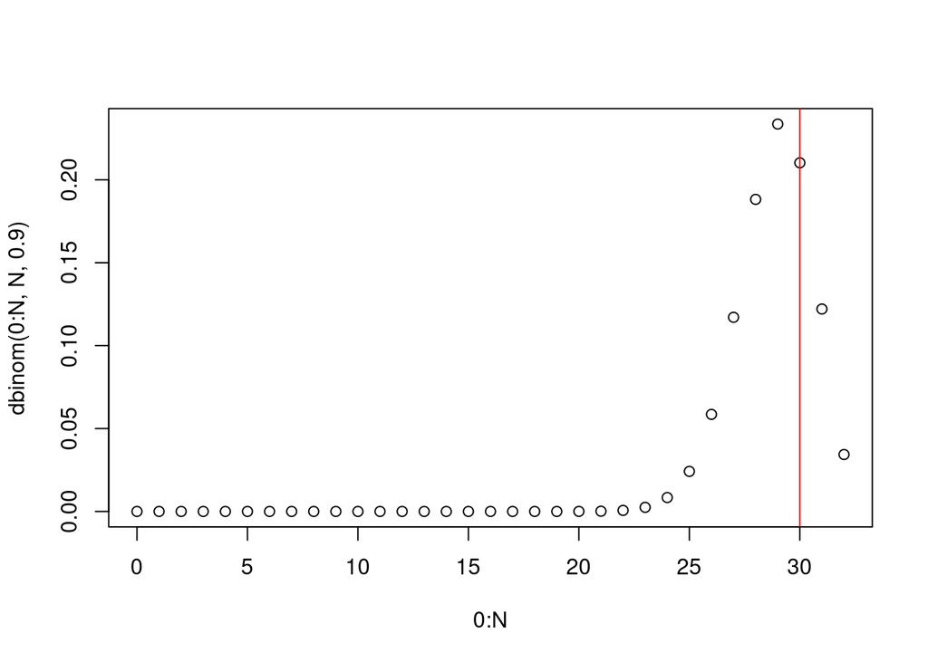

```r
w <- N-sum(df1$Floréal > 105) ## ocio we don't take w*

plot(0:N, dbinom(0:N, N, 0.9))
abline(v = c(w), col='red')
```

Since the Binomial distribution is no longer symmetric (whenever its probability parameter is different from $0.5$), the calculation of the p-value is more complex, *i.e.* we cannot take one tail’s mass and double it anymore [^7]

As we saw before, once we build the statistic, we can apply the function:

```r
binom.test(w, N, 0.90, alternative="two.sided", conf.level = 1-ALPHA)
```

```
##
##  Exact binomial test
##
## data:  w and N
## number of successes = 30, number of trials = 32, p-value = 0.7664
## alternative hypothesis: true probability of success is not equal to 0.9
## 99 percent confidence interval:
##  0.7411892 0.9967194
## sample estimates:
## probability of success
##                 0.9375
```

We fail to reject $H_0$: we have no statistical evidence to conclude the $.90th$ quantile of $X_{floréal}$ is not $105$.

#### Exercise

Re-do the simulations of before, sampling from an univariate distribution, to verify if the power curve of Wicoxon’s signed-rank test is higher than that of the sign test when doing inference on the median.

### Two-sample paired tests

Whenever we have paired data, i.e $p$ random samples where each statistical unit is a measure of a same entity (think about the curves: for different months we have different measurements, but corresponding to a same curve). Say we have $X_{floréal}$ and $X_{prairial}$:

If we are interested in
$$H_0: Med({X}_{floréal}-{X}_{prairial}) = 0 \, \, vs.\, \, H_1:
({X}_{floréal}-{X}_{prairial}) \neq 0$$
we can just apply a **sign test** *OR* a Wilcoxon signed-rank test for the median to the univariate vector of differences $\mathcal{X}_{floréal}-\mathcal{X}_{prairial}$.

For example, say we want to test whether there was an increase from *Floréal* month to *Vendémmiaire*: we have
$$H_0: \mathbb{P}[{X}_{vendémmiaire} > {X}_{floréal}] = 0.5
\,\, \bigg[MED({X}_{vendémmiaire}-{X}_{floréal})=0\bigg] \\
vs\\
H_1:\mathbb{P}[{X}_{vendémmiaire} > {X}_{floréal}] > 0.5
\,\, \bigg[MED({X}_{vendémmiaire}-{X}_{floréal})>0\bigg]$$
(note of course it is a one-sided test). It is actually quite simple! We treat ${X}_{vendémmiaire}-{X}_{floréal}$ as an univariate random variable (say $Y$) and that’s it.

```r
Y <- df1$Vendémmiaire - df1$Floréal

# Prof. Vantini's code
n <- length(Y)
ranks <- rank(abs(Y))
W.plus  <- sum(ranks[Y > 0])
W.minus <- sum(ranks[Y < 0])

W.plus
```

```
## [1] 61
```

```r
W.minus
```

```
## [1] 467
```

```r
n*(n+1)/2
```

```
## [1] 528
```

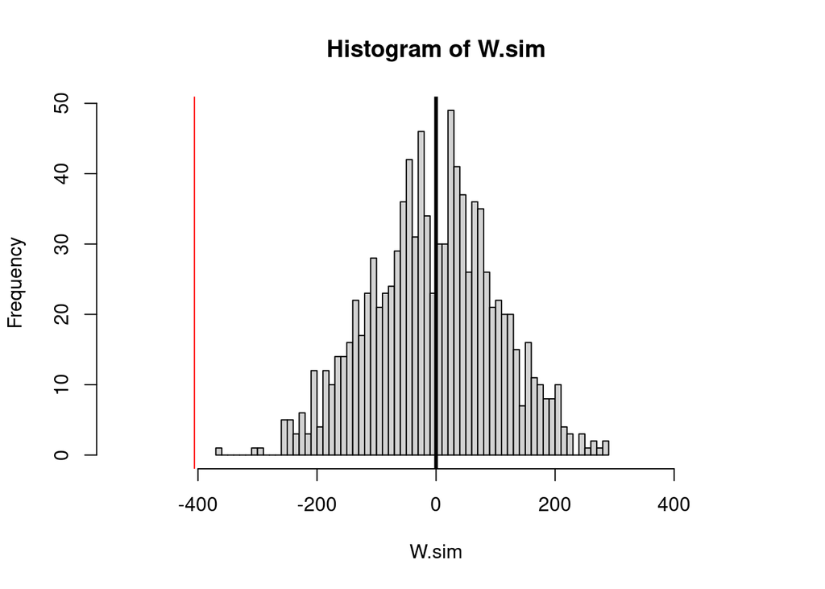

```r
W <- W.plus - W.minus
# W <- sum(sign(differences)*rank(abs(differences)))
#W

# MC computation of the p-value
# Generation of W under the null hypothesis
set.seed(24021979)
W.sim <- numeric(B)
for (k in 1:B)
{
  ranks.temp <- sample(1:n)
  signs.temp <- 2*rbinom(n, 1, 0.5) - 1
  W.temp <- sum(signs.temp*ranks.temp)
  W.sim[k] <- W.temp
}

hist(W.sim, xlim=c(-n*(n+1)/2, n*(n+1)/2), breaks = 50)
abline(v = W, col='red')
abline(v = 0, lwd=3)
```

```r
sum(W <= W.sim)/B
```

```
## [1] 1
```

Alternatively:

```r
wilcox.test(x=df1$Vendémmiaire, y=df1$Floréal, paired=T, alternative = "greater")
```

```
##
##  Wilcoxon signed rank exact test
##
## data:  df1$Vendémmiaire and df1$Floréal
## V = 61, p-value = 1
## alternative hypothesis: true location shift is greater than 0
```

## Multiple testing

Let us retake the permutational t-test. Our only assumption is that the two samples $\mathcal{X}_1$ and $\mathcal{X}_2$ are independent of each other and conformed by iid observations. We may be interested in differences both in location and scale. The solution: build a “custom” test statistic that measures deviations in both:

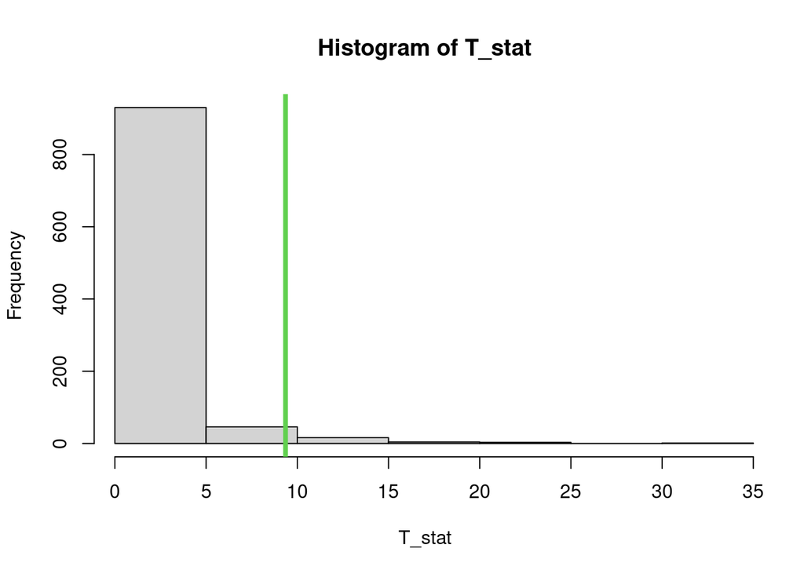

```
## [1] 0.027
```

```r
perm_t_test=function(x,y,iter=1e3, plot=T){

  T0 = max( c(median(y)/median(x), mad(y)/mad(x)) )
  # alternative: mean(y)/mean(x) + sd(y)/sd(x)

  # NB use the ratio so that if H0 both should be 1
  T_stat=numeric(iter) # a vector to store the values of each iteration
  x_pooled=c(x,y) # pooled sample
  n=length(x_pooled)
  n1=length(x)
 # print(sprintf("Using %s iterations to estimate the permutational distribution. There are actually %s possible permutations", iter, factorial(n)))
  for(perm in 1:iter){ # loop for conditional MC
    # permutation:
    permutation <- sample(1:n)
    x_perm <- x_pooled[permutation]
    x1_perm <- x_perm[1:n1]
    x2_perm <- x_perm[(n1+1):n]
    # test statistic:
    T_stat[perm] <- max(c(median(x2_perm)/ median(x1_perm),
                          mad(x2_perm) / mad(x1_perm)
                          )
      )

  }

  # p-value
  if (plot){
      hist(T_stat,xlim=range(c(T_stat,T0)))
    abline(v=T0,col=3,lwd=4)

  }

  p_val <- sum(T_stat>=T0)/iter
  return(p_val)
}
set.seed(1909)
# case of different variance
perm_t_test(x=rstable(30,1.5,0), y=rstable(30,1.5,0)+runif(30, min=-15, max=15), iter=1e3)
```

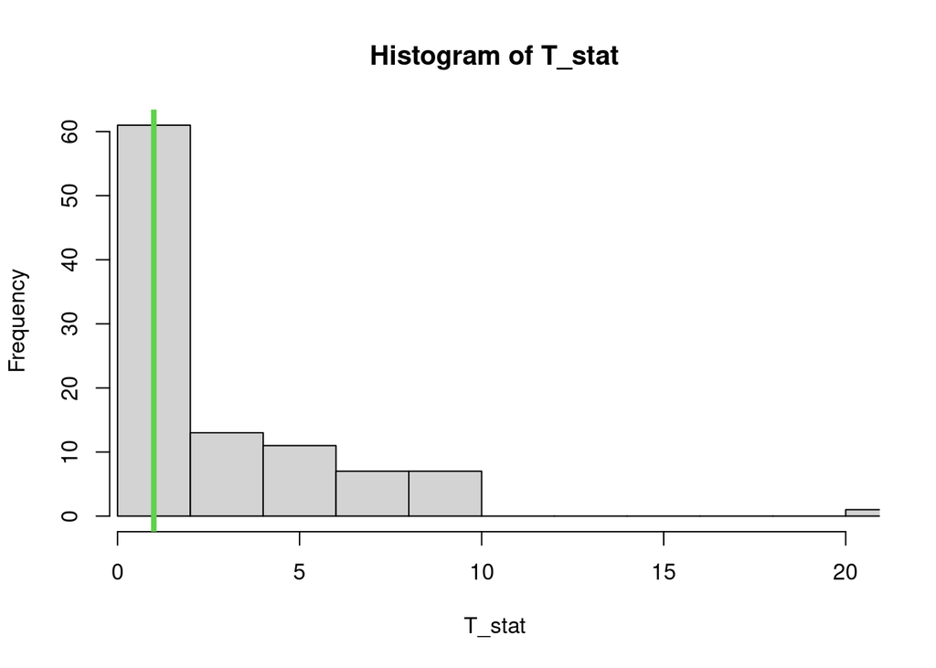

```
## [1] 0.71
```

```r
# case of different mean
perm_t_test(x=rstable(30,1.5,0), y=rstable(30,1.5,0)+10, iter=1e2)
```

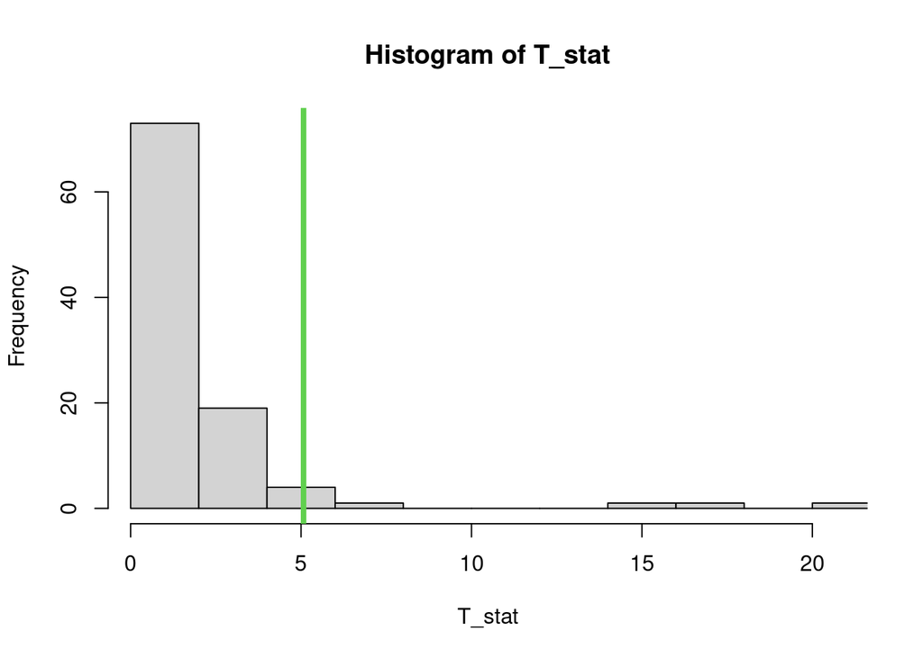

```
## [1] 0.05
```

```r
# case of different both
perm_t_test(x=rstable(30,1.5,0), y=rstable(30,1.5,0)+10+runif(30, min=-15, max=15), iter=1e2)
```

Naturally, the power depends on your choice of your test statistic. Yet its type I error should be the nominal one, i.e. $\alpha$.

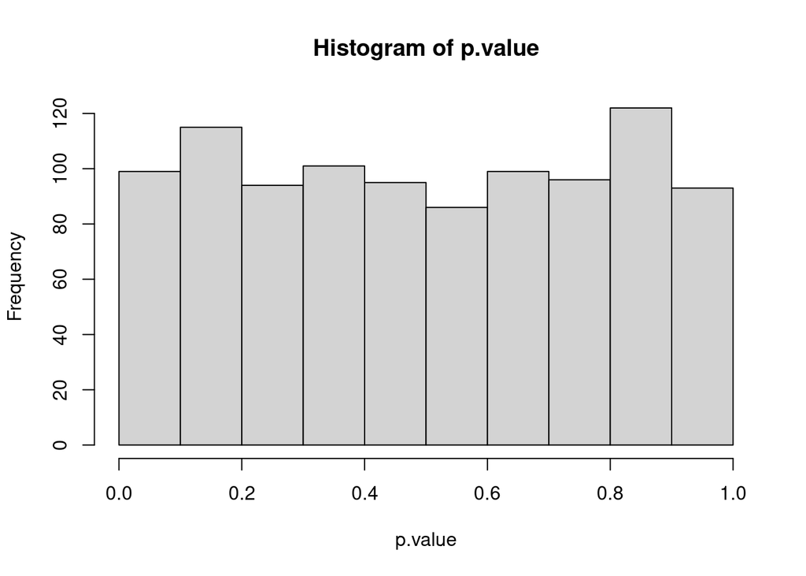

```r
p.value <- numeric(B)
set.seed(20)
n = 30
sigma = 1
for(j in 1:B){
  # sample from the normal distribution
  x1 <- rnorm(n,sd=sigma)
  x2 <- rnorm(n,sd=sigma)
  p.value[j] <- perm_t_test(x=x1, y=x2, iter=100, plot=F)
}
hist(p.value)
```

and indeed we get the expected uniform distribution for a test repeated $B$ times with the null being true.